# White Wine Quality Analysis - Divya Chandramouli

#### Density vs residual sugar by quality bucket

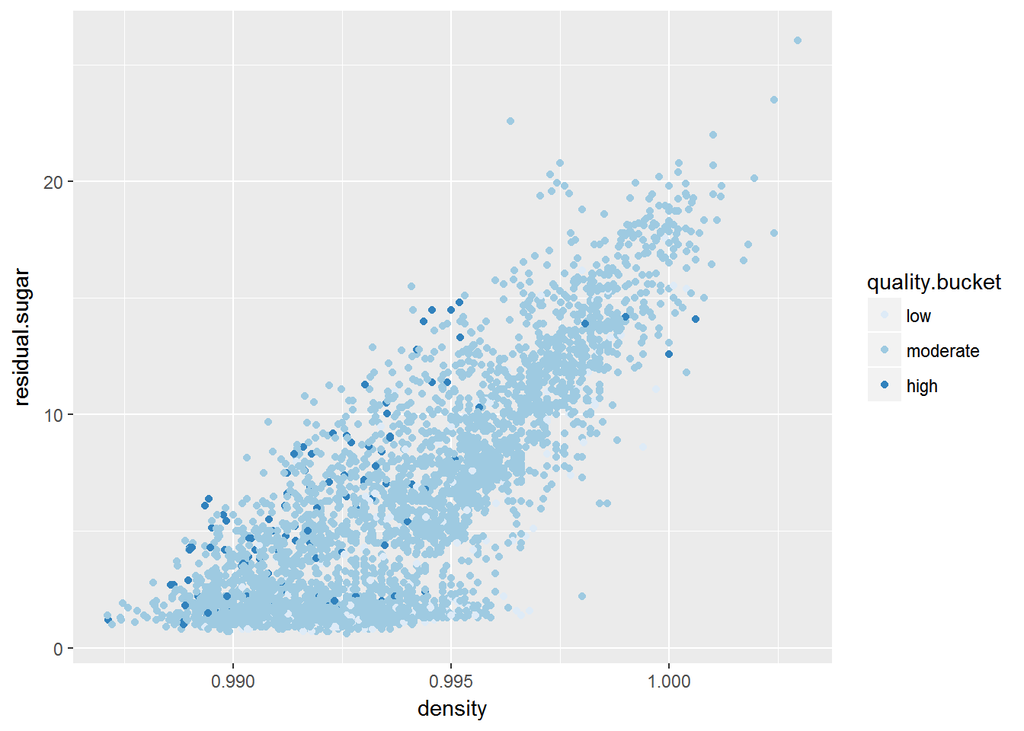

The gradient in color denoting quality is not very clear. There is overplotting and the moderate quality wines are dominant

Let us subset the data to look at only low and high quality wines to see if we can get clearer insight

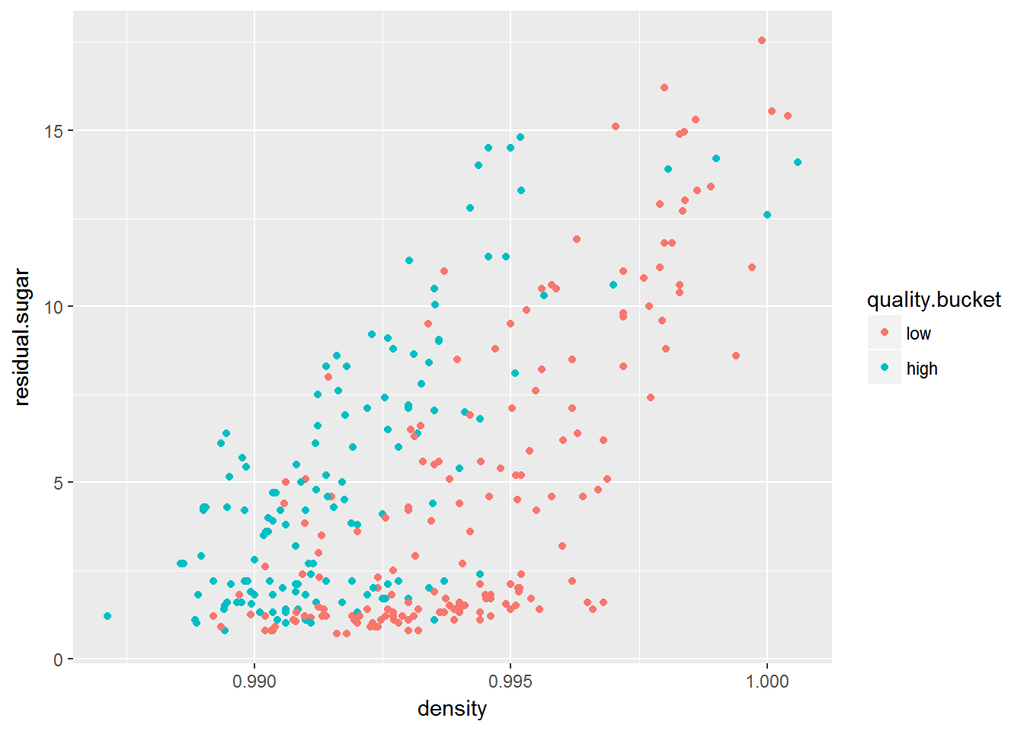

For a fixed value of density, the higher quality wines have more residual sugar than the lower quality wines which is interesting.

Now let us color the density vs residual sugar plot by alcohol bucket

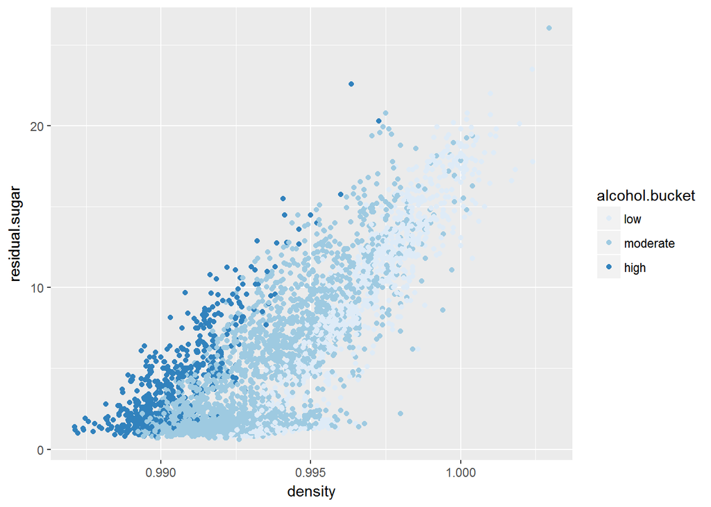

Here the gradient in color denoting alcohol bucket looks very interesting For a fixed density, wines with higher residual sugar have greater alcohol content. At higher levels of residual sugar, the density is higher and alcohol content is lower

Let us facet the density vs residual sugar plot colored by alcohol using quality.discrete

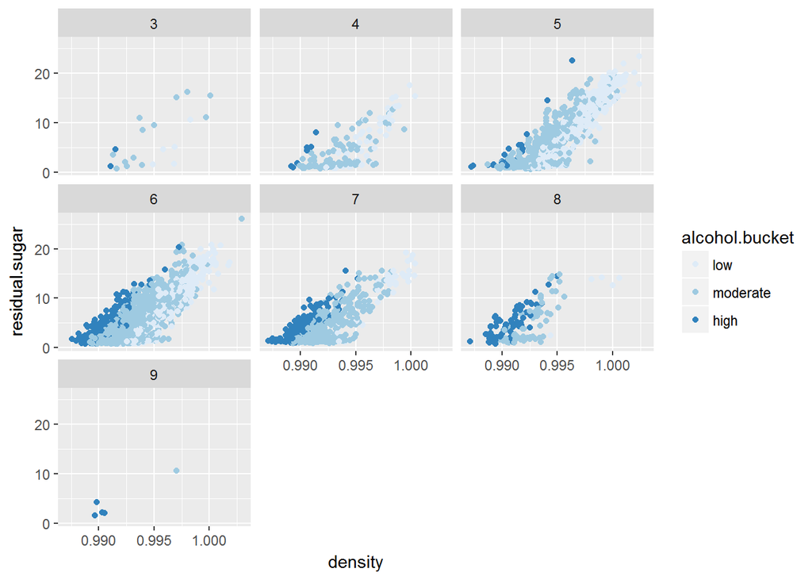

The plots with lower quality ratings are dominated by wines with lower alcohol As the quality rating increases, wines have higher alcohol and lower density

#### Density vs alcohol level, by quality bucket

Let us add quality bucket tto our density vs alcohol plot excluding density outliers

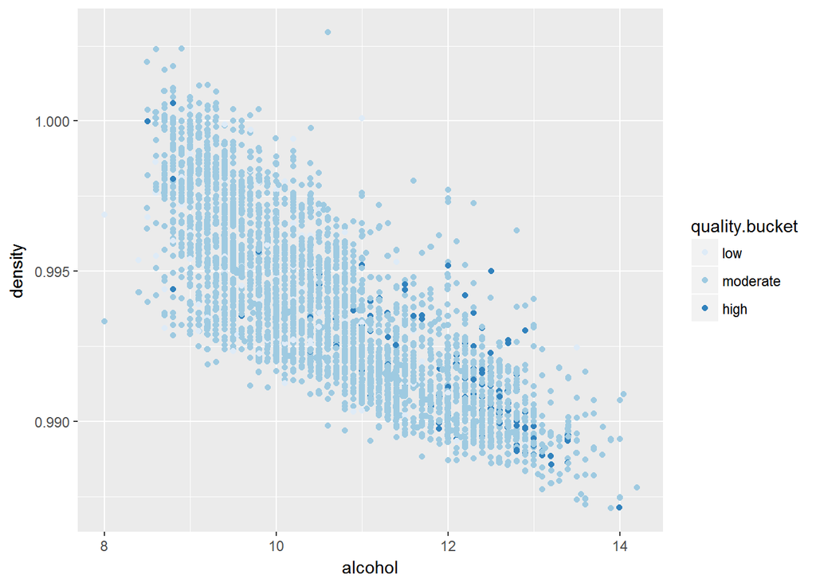

Again we see that the moderate quality wines are dominant Let us subset the data to include only low and high quality wines

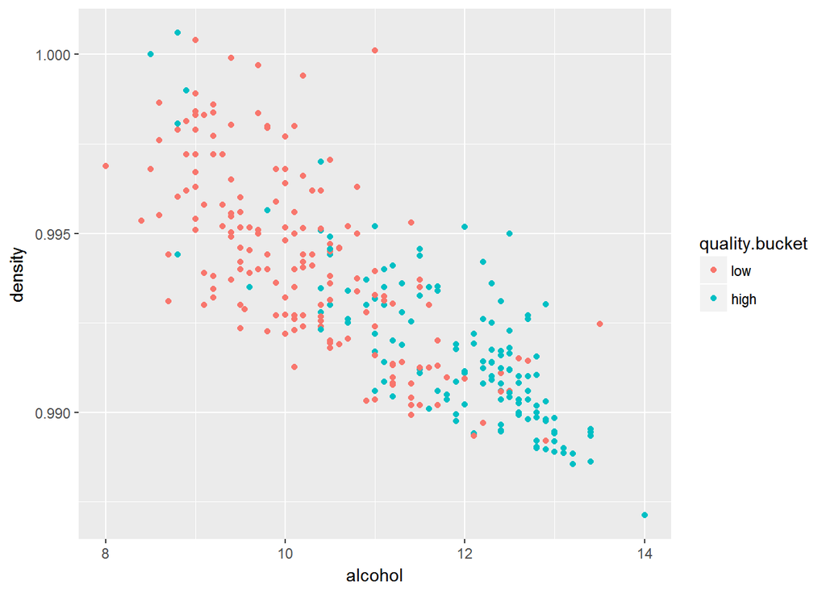

This plot shows us that wines with higher quality have higher alcohol content and lower density. At lower alcohol levels, the variation in density is more

Let us color the density vs alcohol plot by residual sugar

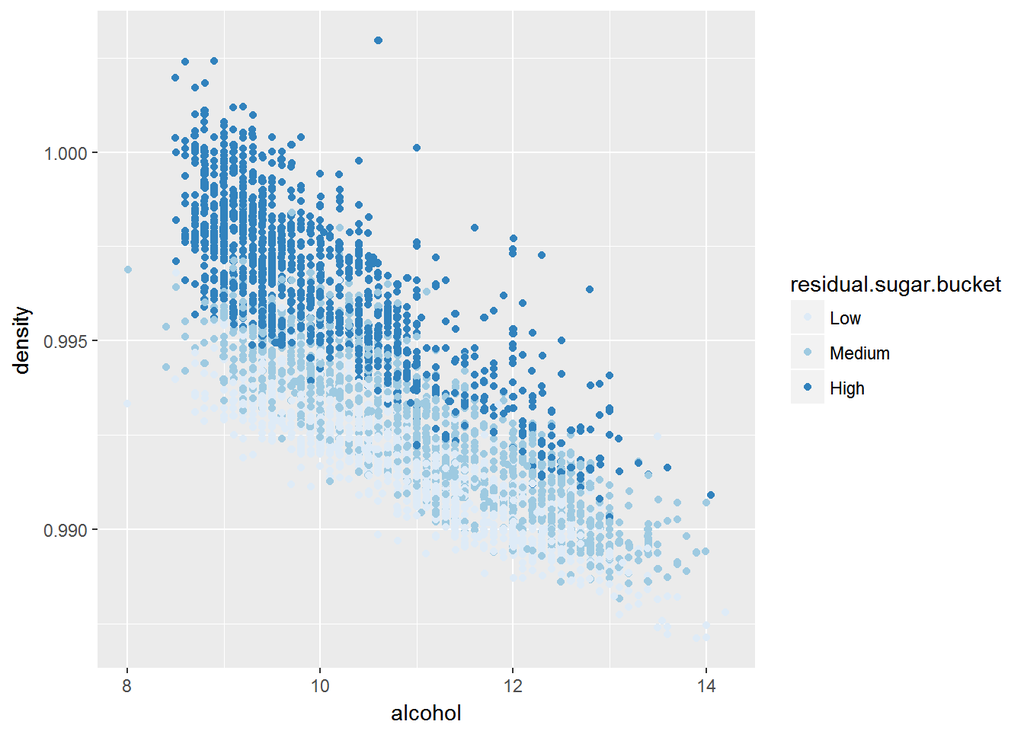

We can seethat wines with higher residual sugar have higher density for the same alcohol content

Now let’s facet this graph by quality

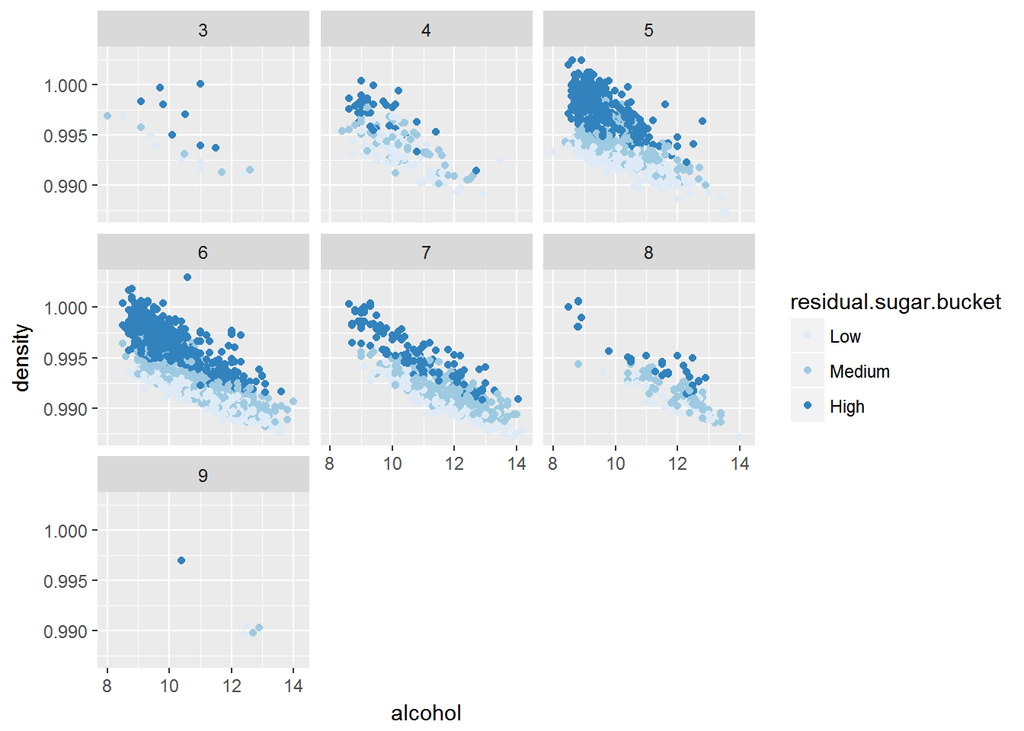

The variation in density decreases as quality gets better. the plots with medium quality ratingsare dominated by wines with high residual sugar

Since alcohol vs quality was the strongest relationship we saw among all the relationships with quality, let’s explore that by coloring it by residual sugar

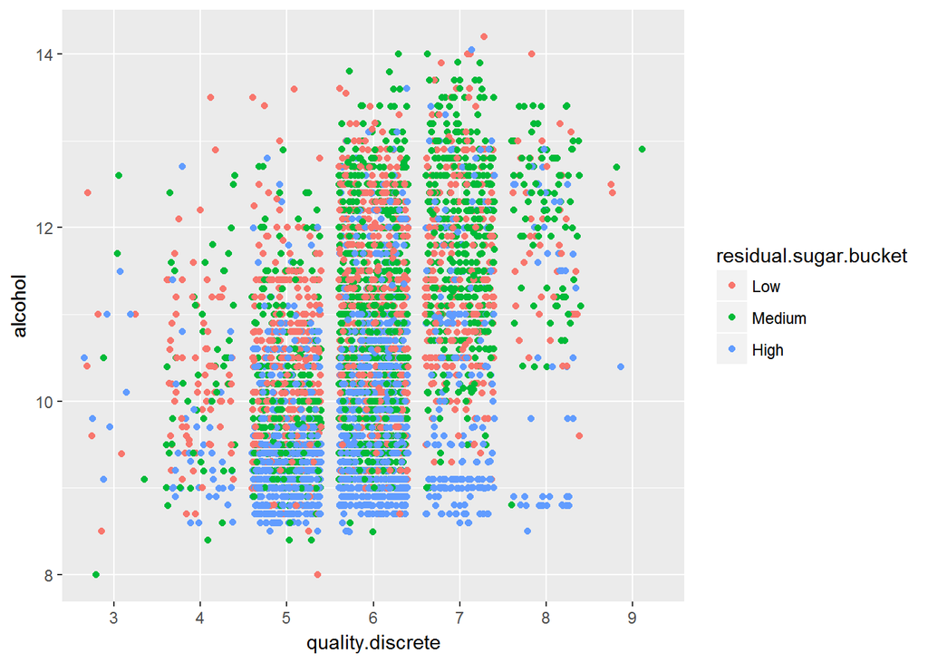

The buckets of residual sugar seem to be distributed among the levels of quality with a slight domination of high residual sugar in the moderate ratings of quality. Not much can be ascertained about the influence of residual sugar on quality.

As quality increases the alcohol content increases and the variation in alcohol content decreases

#### Quality Prediction Model

Let’s try to build a mdel to predict quality given the values for a few properties.Since quality is not strongly correlated with any of the features the accuracy of the model cannot be expected to be high

Let’s try using alcohol as the first feature since the correlation with alcohol was highest for quality, The other features I’m choosing are: density, chlorides and residual sugar

```
##
## Calls:
## m1: lm(formula = I(quality) ~ I(alcohol), data = wq)
## m2: lm(formula = I(quality) ~ I(alcohol) + density, data = wq)
## m3: lm(formula = I(quality) ~ I(alcohol) + density + chlorides, data = wq)
## m4: lm(formula = I(quality) ~ I(alcohol) + density + chlorides +
##     residual.sugar, data = wq)
##
## ==========================================================================
##                        m1            m2            m3            m4
## --------------------------------------------------------------------------
##   (Intercept)         2.582***    -22.492***    -21.150***     87.563***
##                      (0.098)       (6.165)       (6.162)      (12.392)
##   I(alcohol)          0.313***      0.360***      0.343***      0.237***
##                      (0.009)       (0.015)       (0.015)       (0.018)
##   density                          24.728***     23.671***    -84.931***
##                                    (6.079)       (6.074)      (12.340)
##   chlorides                                      -2.382***     -1.776**
##                                                  (0.558)       (0.555)
##   residual.sugar                                                0.052***
##                                                                (0.005)
## --------------------------------------------------------------------------
##   R-squared           0.190         0.192         0.195         0.212
##   adj. R-squared      0.190         0.192         0.195         0.211
##   sigma               0.797         0.796         0.795         0.787
##   F                1146.395       583.290       396.315       328.736
##   p                   0.000         0.000         0.000         0.000
##   Log-likelihood  -5839.391     -5831.127     -5822.011     -5771.696
##   Deviance         3112.257      3101.773      3090.247      3027.406
##   AIC             11684.782     11670.255     11654.021     11555.391
##   BIC             11704.272     11696.241     11686.504     11594.371
##   N                4898          4898          4898          4898
## ==========================================================================
```

The R square values are very poor which implies we will have to adopt a better approach to building a predictive model for quality. Using more relevant features and complex methods may help build a better predictive model for quality

### Multivariate Analysis

#### Talk about some of the relationships you observed in this part of the investigation.Were there features that strengthened each other in terms of looking at your feature(s) of interest?

Quality was the main feature of interest. Density and alcohol levels seemed to influence quality and the relationships were explored more in detail by introducing bucket variables for alcohol, quality, density and residual sugar. But since none of the relationships were strong enough to build a predictive model for quality, the R squared values for the linear model are poor

#### Were there any interesting or surprising interactions between features?

It was interesting to observe the variation in density / alcohol levels as the quality gets better. Faceting plots by quality and coloring them with a feature helped to understand and explain some trends

#### OPTIONAL: Did you create any models with your dataset? Discuss the strengths and limitations of your model.

I tried to create a linear predictive model for quality using alcohol, density, chlorides and residual sugar. Since the strength of relationships with quality was not great, the model does very poorly. More data with relevant features and more complex methods may help to build a better model.

### Final Plots and Summary

#### Plot One

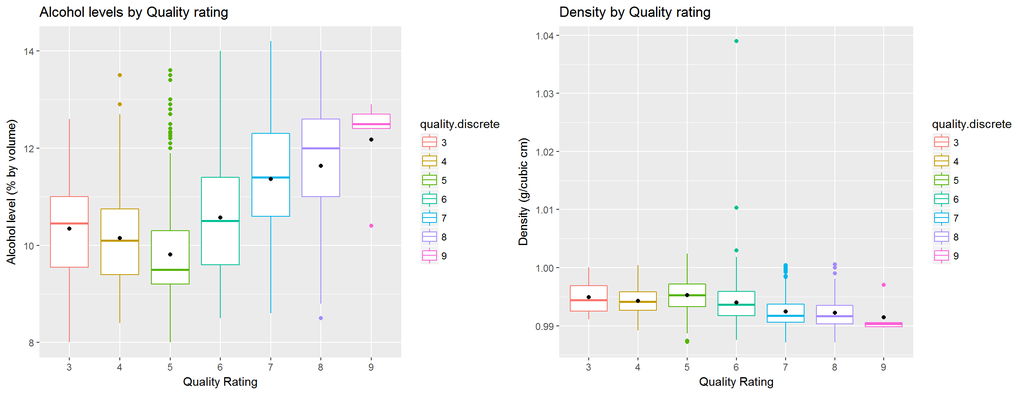

#### Description One

This plot clearly illustrates that higher quality wines have higher alcohol content.The black dots denote the mean alcohol content for every quality level. The increasing trend in alcohol content is very pronounced from rating 5 - 9. The strongest correlation observed with quality was that of alcohol content with a Spearman’s coefficient of 0.44

#### Plot Two

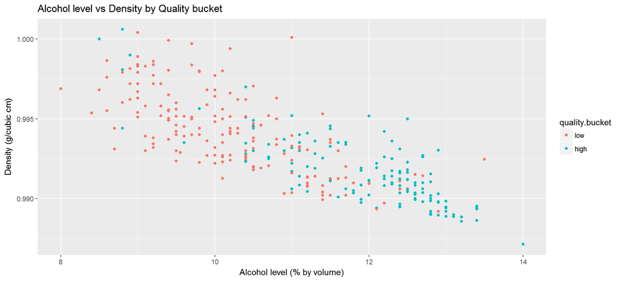

#### Description Two

This graph is colored by quality bucket and shows only the low and high quality wines. It is interesting to see that higher alcohol content corresponds to lesser density (alcohol is less denser than water). From Plot one and two, we can infer that higher quality wines have higher alcohol and lesser density

#### Plot Three

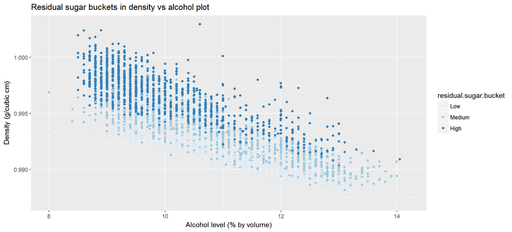

#### Description Three

The variance in density with decreasing alcohol content is accounted for by the residual sugar levels in wine. Density, alcohol and residual sugar were part of strong correlations and this plot summarizes their relationship. When this plot was faceted by quality it could further help in picturing the variation of these parameters with quality.

### Reflection

Univariate exploration helped get an idea about the individual distributions of data and it was interesting to apply transformations and see their effect.  
I had expected residual sugar to be a direct influencer of taste and therefore quality since the quality rating is sensory data. It turned out that residual sugar correlated with density strongly and explained the variance in density over alcohol and quality levels.

The interesting part of the exploration was investigating the strong relationships between density and residual sugar, density and alcohol and connecting them to quality ratings using colored and faceted plots.

The linear predictive model for quality was built using alcohol, density, chlorides and residual sugar. Since the strength of relationships with quality is not great, the model does very poorly. More data with relevant features and more complex methods may help to build a better model

### Resources

https://www.rdocumentation.org/packages/GGally/versions/1.3.2/topics/ggpairs

https://www.rdocumentation.org/packages/memisc/versions/0.99.14.9/topics/mtable

https://s3.amazonaws.com/udacity-hosted-downloads/ud651/wineQualityInfo.txt